# 02 Prep Events Locations

Rex W. Douglass and Kristen Harkness

12/9/2017

Cleans and converts location information in the event dataset and saves as a spatial R object for analysis.

# Loads

```r
rm(list=ls()); gc()
library(MeasuringLandscapeCivilWar)
devtools::load_all()
knitr::opts_knit$set(progress = TRUE, verbose = TRUE)
knitr::opts_chunk$set(fig.width=12, fig.height=8,  warning=FALSE, message=FALSE, cache=TRUE)
options(width = 160)
events <- readRDS(system.file("extdata", "MeasuringLandscapeCivilWar_events_cleaned.Rdata", package = "MeasuringLandscapeCivilWar"))
dim(events)
```

# Clean Map Coordinates (East Africa Grid System)

```r
cat("\014")
```

```r
#Cases to handle
#"928141"
#"311449  328445    338443"
#"EASTING 30 and 27"
#"EastLeigh Sect.7"
#"FARM 535/4"
#"HAC  0202"
#"HAC.577236"
#"HZN 974641 & HZN 974651"
#"HZJ. 8595"
#"HZJ. 465765, HZJ. 459771, HZJ. 451756"
#"HZJ 42765, HZJ 42375and HZJ 429761"
#"HZH 960610, HZH 960630, HZH 977538"
#"H.Z.R. 4786"
#"HAD 1708, HAD 1709"
#"HAD 3326/3327"
#"HZJ 42765, HZJ 42375and HZJ 429761"
#"HZJ 9518  9617"
#"HZP 7430, HZP 9029, HZP 6448, HZP 7252, HZP 9448"
events$map_coordinate %>% tabyl()
```

| . | n | percent | valid_percent |
| --- | --- | --- | --- |
| ?? | 1 | 9.552011e-05 | 0.0001717918 |
| 1182 | 1 | 9.552011e-05 | 0.0001717918 |
| 1200 | 1 | 9.552011e-05 | 0.0001717918 |
| 12053 | 1 | 9.552011e-05 | 0.0001717918 |
| 12402 | 1 | 9.552011e-05 | 0.0001717918 |
| 1280 | 1 | 9.552011e-05 | 0.0001717918 |
| 1281 | 1 | 9.552011e-05 | 0.0001717918 |
| 1663 | 1 | 9.552011e-05 | 0.0001717918 |
| 184157 | 1 | 9.552011e-05 | 0.0001717918 |
| 1870 | 2 | 1.910402e-04 | 0.0003435836 |

[output cut: 990 more lines]

```r
events$map_coordinate_clean <- events$map_coordinate %>% str_replace_all("[[:punct:]]| ", "")
(events$map_coordinate_clean_length <- events$map_coordinate_clean %>% nchar() ) %>% tabyl() %>% round(3)
```

| . | n | percent | valid_percent |
| --- | --- | --- | --- |
| 0 | 1 | 0.000 | 0.000 |
| 3 | 10 | 0.001 | 0.002 |
| 4 | 110 | 0.011 | 0.019 |
| 5 | 11 | 0.001 | 0.002 |
| 6 | 29 | 0.003 | 0.005 |
| 7 | 3155 | 0.301 | 0.542 |
| 8 | 38 | 0.004 | 0.007 |
| 9 | 2414 | 0.231 | 0.415 |
| 10 | 6 | 0.001 | 0.001 |
| 11 | 10 | 0.001 | 0.002 |

[output cut: 12 more lines]

```r
(events$map_coordinate_clean_text <- events$map_coordinate_clean %>% gsub("[0-9]", "\\1",.)) %>% tabyl()  %>% mutate_if(is.numeric, round,2) #Split into a text component and numeric component
```

| . | n | percent | valid_percent |
| --- | --- | --- | --- |
|  | 141 | 0.01 | 0.02 |
| EASTINGand | 1 | 0.00 | 0.00 |
| EastLeighSect | 1 | 0.00 | 0.00 |
| FARM | 1 | 0.00 | 0.00 |
| GZM | 1 | 0.00 | 0.00 |
| H | 1 | 0.00 | 0.00 |
| HAA | 1 | 0.00 | 0.00 |
| HAB | 249 | 0.02 | 0.04 |
| HAC | 334 | 0.03 | 0.06 |
| HACHZRHZR | 1 | 0.00 | 0.00 |

[output cut: 54 more lines]

```r
(events$map_coordinate_clean_number <- events$map_coordinate_clean %>% gsub("[A-Za-z]", "\\1", .) ) %>% tabyl()  %>% mutate_if(is.numeric, round,2)
```

| . | n | percent | valid_percent |
| --- | --- | --- | --- |
|  | 13 | 0 | 0 |
| 000720 | 2 | 0 | 0 |
| 0008 | 4 | 0 | 0 |
| 001500 | 1 | 0 | 0 |
| 0020 | 1 | 0 | 0 |
| 002312 | 1 | 0 | 0 |
| 002559 | 1 | 0 | 0 |
| 0033 | 2 | 0 | 0 |
| 003370 | 2 | 0 | 0 |
| 003510 | 1 | 0 | 0 |

[output cut: 990 more lines]

```r
(events$map_coordinate_clean_text_band <- events$map_coordinate_clean_text %>% substring(1,1) ) %>% tabyl()  %>% mutate_if(is.numeric, round,2)
```

| . | n | percent | valid_percent |
| --- | --- | --- | --- |
|  | 141 | 0.01 | 0.02 |
| E | 2 | 0.00 | 0.00 |
| F | 1 | 0.00 | 0.00 |
| G | 1 | 0.00 | 0.00 |
| h | 1 | 0.00 | 0.00 |
| H | 5662 | 0.54 | 0.97 |
| K | 1 | 0.00 | 0.00 |
| L | 2 | 0.00 | 0.00 |
| M | 3 | 0.00 | 0.00 |
| N | 5 | 0.00 | 0.00 |

[output cut: 3 more lines]

```r
(events$map_coordinate_clean_text_block <- events$map_coordinate_clean_text %>% substring(2,2) ) %>% tabyl()  %>% mutate_if(is.numeric, round,2)
```

| . | n | percent | valid_percent |
| --- | --- | --- | --- |
|  | 142 | 0.01 | 0.02 |
| a | 2 | 0.00 | 0.00 |
| A | 663 | 0.06 | 0.11 |
| D | 1 | 0.00 | 0.00 |
| E | 4 | 0.00 | 0.00 |
| h | 1 | 0.00 | 0.00 |
| J | 2 | 0.00 | 0.00 |
| L | 3 | 0.00 | 0.00 |
| n | 1 | 0.00 | 0.00 |
| o | 1 | 0.00 | 0.00 |

[output cut: 8 more lines]

```r
(events$map_coordinate_clean_text_subblock <-  events$map_coordinate_clean_text %>%  substring(3,3) ) %>% tabyl()  %>% mutate_if(is.numeric, round,2)
```

| . | n | percent | valid_percent |
| --- | --- | --- | --- |
|  | 150 | 0.01 | 0.03 |
| A | 2 | 0.00 | 0.00 |
| B | 252 | 0.02 | 0.04 |
| c | 1 | 0.00 | 0.00 |
| C | 335 | 0.03 | 0.06 |
| D | 71 | 0.01 | 0.01 |
| E | 1 | 0.00 | 0.00 |
| G | 15 | 0.00 | 0.00 |
| H | 150 | 0.01 | 0.03 |
| J | 679 | 0.06 | 0.12 |

[output cut: 14 more lines]

```r
(events$map_coordinate_clean_number_length <- events$map_coordinate_clean_number %>% nchar() ) %>% tabyl()  %>% mutate_if(is.numeric, round,2)
```

| . | n | percent | valid_percent |
| --- | --- | --- | --- |
| 0 | 13 | 0.00 | 0.00 |
| 1 | 1 | 0.00 | 0.00 |
| 2 | 4 | 0.00 | 0.00 |
| 3 | 9 | 0.00 | 0.00 |
| 4 | 3270 | 0.31 | 0.56 |
| 5 | 41 | 0.00 | 0.01 |
| 6 | 2433 | 0.23 | 0.42 |
| 7 | 7 | 0.00 | 0.00 |
| 8 | 21 | 0.00 | 0.00 |
| 10 | 2 | 0.00 | 0.00 |

[output cut: 6 more lines]

```r
(events$map_coordinate_clean_number_easting <- events$map_coordinate_clean_number %>%
                                              substring(1, events$map_coordinate_clean_number_length/2) %>% as.numeric() ) %>%
                                              tabyl()  %>% mutate_if(is.numeric, round,2)
```

| . | n | percent | valid_percent |
| --- | --- | --- | --- |
| 0 | 28 | 0.00 | 0.00 |
| 1 | 29 | 0.00 | 0.00 |
| 2 | 34 | 0.00 | 0.01 |
| 3 | 35 | 0.00 | 0.01 |
| 4 | 50 | 0.00 | 0.01 |
| 5 | 51 | 0.00 | 0.01 |
| 6 | 20 | 0.00 | 0.00 |
| 7 | 20 | 0.00 | 0.00 |
| 8 | 26 | 0.00 | 0.00 |
| 9 | 25 | 0.00 | 0.00 |

[output cut: 828 more lines]

```r
(events$map_coordinate_clean_number_northing <- events$map_coordinate_clean_number %>%
                                              substring(events$map_coordinate_clean_number_length/2+1, events$map_coordinate_clean_number_length) %>%
                                              as.numeric() )  %>%
                                              tabyl()  %>% mutate_if(is.numeric, round,2)
```

| . | n | percent | valid_percent |
| --- | --- | --- | --- |
| 0 | 39 | 0.00 | 0.01 |
| 1 | 40 | 0.00 | 0.01 |
| 2 | 26 | 0.00 | 0.00 |
| 3 | 39 | 0.00 | 0.01 |
| 4 | 38 | 0.00 | 0.01 |
| 5 | 49 | 0.00 | 0.01 |
| 6 | 33 | 0.00 | 0.01 |
| 7 | 43 | 0.00 | 0.01 |
| 8 | 35 | 0.00 | 0.01 |
| 9 | 50 | 0.00 | 0.01 |

[output cut: 840 more lines]

## Convert Coordinates to lat long

```r
#This takes
cat("\014")
print("Starting Converting Coordinates, may take some time")
for(i in 1:nrow(events)){
  # print(i)
  suppressMessages({
    temp <- events[i,] %$% EAGS2LatLong(band=map_coordinate_clean_text_band,
                                        block=map_coordinate_clean_text_block,
                                        subblock=map_coordinate_clean_text_subblock,
                                        easting=map_coordinate_clean_number_easting ,
                                        northing=map_coordinate_clean_number_northing)
    events$map_coordinate_clean_latitude[i] <- temp$latitude
    events$map_coordinate_clean_longitude[i] <- temp$longitude
  })
  #print(is.na(events$map_coordinate_clean_latitude[i]))
}
print("Finished Converting Coordinates")
```

```r
#(temp <- events %>% mutate(map_coordinate_clean_row=1:n()) %>% filter(is.na(map_coordinate_clean_latitude) & !is.na(map_coordinate_clean)) %>% select(starts_with("map_coordinate_clean")) ) %>% distinct() %>% print(n=40) #visualize errors
#dim(temp) #195 coordinates don't convert.
testing=F
if(testing){
  i=3684
  events[i,] %>%  select(starts_with("map_coordinate_clean")) %$% EAGS2LatLong(band=map_coordinate_clean_text_band,
                                                                              block=map_coordinate_clean_text_block,
                                                                              subblock=map_coordinate_clean_text_subblock,
                                                                              easting=map_coordinate_clean_number_easting ,
                                                                              northing=map_coordinate_clean_number_northing)

  with(events[i,], map_coordinate_clean)
  with(events[i,], map_coordinate)
  band <- with(events[i,], map_coordinate_clean_text_band)
  block <- with(events[i,],map_coordinate_clean_text_block)
  subblock <- with(events[i,],map_coordinate_clean_text_subblock) #
  easting <- with(events[i,],map_coordinate_clean_number_easting)
  northing <- with(events[i,],map_coordinate_clean_number_northing)
}
stats::quantile(events$map_coordinate_clean_latitude, probs =c(.005,.01,.1,.5,.9,.99,.995), na.rm=T, type=9)
```

```
      0.5%         1%        10%        50%        90%        99%      99.5%
-1.7190692 -1.5442831 -1.0403576 -0.4886414  0.0452442  0.7058103  2.2342679
```

```r
stats::quantile(events$map_coordinate_clean_longitude, probs =c(.005,.01,.1,.5,.9,.99,.995), na.rm=T, type=9)
```

```
    0.5%       1%      10%      50%      90%      99%    99.5%
35.67124 35.78910 36.36309 36.93511 37.45506 38.26145 39.87161
```

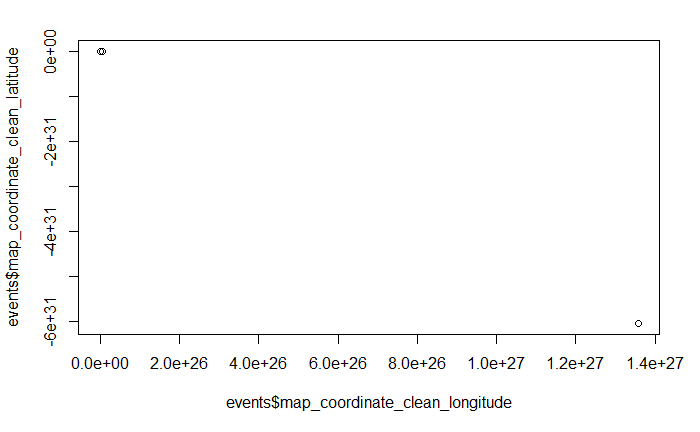

```r
plot(events$map_coordinate_clean_longitude,events$map_coordinate_clean_latitude)
```

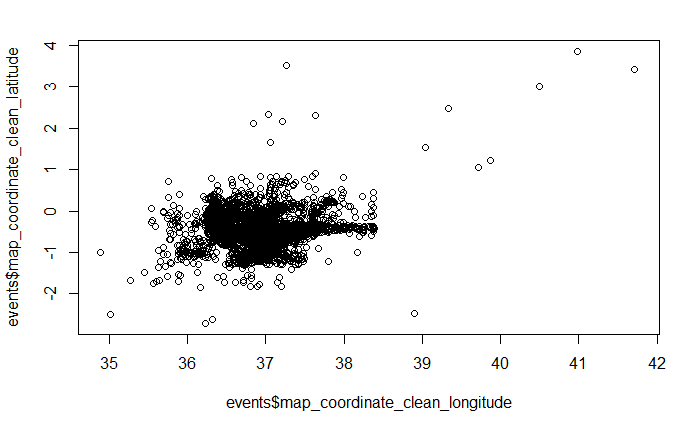

```r
#This is just to remove absolutely clear outliers. Not to set the region of interest.
#Outlier Bounding Box:
#NE 4.62933, 41.899059
#SW -4.71712, 33.90884
events$map_coordinate_clean_latitude[events$map_coordinate_clean_latitude < -4.71712 |
                                      events$map_coordinate_clean_latitude>4.62933] <- NA
events$map_coordinate_clean_longitude[events$map_coordinate_clean_longitude < 33.90884 |
                                      events$map_coordinate_clean_longitude>41.899059] <- NA
plot(events$map_coordinate_clean_longitude,events$map_coordinate_clean_latitude)
```

# District of Document

-Likewise, the plots suggest some district cleaning still necessary. Jock Scott was an operation in Nairobi and all of those can be changed to Nairobi. Central Province and Rift Valley Province are not districts. Not sure if that matters at this stage… but we probably want to reassign the points we can geolocate from them to an actual district.

Districts: -Jock Scott, rift valley, and central province aren’t districts. I think Jock Scott is a small town within a district, not sure which one. Central province and rift valley are provinces, one administrative unit higher than the district. -the districts should be: Baringo, Elgeyo/Marakwet, Embu, Fort Hall, Kajiado, Kiambu, Kitui, Laikipia, Machakos, Meru, Naivasha, Nakuru, Nanyuki, Narok, Nyeri, Thika, and then Nairobi City -we retrieved events from both district level and provincial level files and we should make sure that that didn’t create duplicate events -Here is my list of our coverage from the files we looked at (the star means we have complete files for the emergency):

*Baringo Mar 51-Aug 61* Elgeyo/Marakwet Mar 53-Aug 61 Embu Nov 51-Aug 61  
Fort Hall Nov 51-Aug 54 (possibly missing end) Kajiado Aug 53-Aug 61 *Kiambu Nov 51-Aug 61 Kitui Dec 51-Feb 53 (possibly missing end)* Laikipia Nov 51-Dec 57 (Jan 58-Aug 60 in provincial files) Machakos Mar 53-Dec 55 *Meru Dec 51-Aug 61* Naivasha May 53-Dec 57; Jan 58-Aug 60 in provincial files *Nakuru Mar 53-Dec 53; Oct 54-Dec 57; Jan 58-Aug 60 in provincial files* Nanyuki Dec 51-Sep 53; Jan 54-Dec 54; Dec 55-Aug 61 *Narok May 51-Feb 53; Aug 53-Aug 61* Nyeri Nov 51-Aug 61 *Thika Dec 51-Aug 61

Nairobi City Mar 53-Dec 56

Central Province Mar 53-Jan 57

Rift Valley Province Feb 51- Dec 53; Jan 58-Aug 60

```r
cat("\014")
```

```r
#clean document district
p_load(car,stringi,xtable)
events$document_district_clean <- str_trim(stri_trans_totitle(events$document_district))
events$document_district_clean <- events$document_district_clean %>% recode("
                                   'Embu-Fort Hall Border'='Embu';
                                  'BARINGO'='Baringo';
                                   'FORT HALL'='Fort Hall';
                                   'Naviasha'='Naivasha';
                                   'Nyeri Settled Area'='Nyeri';
                                  'South Nyeri Reserve'='Nyeri' ;
                                   'Reference Serial'=NA ;
                                  'H/M'=NA; 'Matathia'=NA;
                                   'Kitui'=NA;
                                  'Jock Scott'='Nairobi';
                                   ''=NA;
                                   ' '=NA ;
                                   'Document District' = NA")
```

NAs introduced by coercion

```r
events$document_unit_type <- NA
condition <- events$document_district_clean %in% c("Rift Valley","Central Province"); table(condition)
```

condition FALSE TRUE 9278 1191

```r
events$document_unit_type[condition] <- "Province"
#Jock Scott Nairobi City
condition <- events$document_district_clean %in% c("Nairobi"); table(condition)
```

condition FALSE TRUE 10075 394

```r
events$document_unit_type[condition] <- "City"
condition <- events$document_district %in% c("JOCK SCOTT"); table(condition)
```

condition FALSE TRUE 10357 112

```r
events$document_unit_type[condition] <- "Operation Jock Scott"
#Missing? Elgeyo/Marakwet
#Baringo, , Embu, Fort Hall, Kajiado, Kiambu, Kitui, Laikipia, Machakos, Meru, Naivasha, Nakuru, Nanyuki, Narok, Nyeri, Thika
condition <- events$document_district_clean %in% c("Baringo","Embu","Fort Hall","Kajiado","Kiambu",
                                                 "Laikipia","Machakos","Meru","Naivasha","Nakuru",
                                                  "Nanyuki","Narok","Nyeri","Thika"); table(condition)
```

condition FALSE TRUE 1596 8873

```r
events$document_unit_type[condition] <- "District"
table(events$document_unit_type, useNA="always")
```

```
            City             District Operation Jock Scott             Province                 <NA>
             282                 8873                  112                 1191                   11
```

```r
districts <- data.frame(sort( table(events$document_district_clean))); names(districts) <- "Count"
kable(districts)
```

| Count | NA |
| --- | --- |
| Baringo | 28 |
| Kajiado | 69 |
| Machakos | 103 |
| Nakuru | 122 |
| Narok | 294 |
| Nairobi | 394 |
| Thika | 407 |
| Rift Valley | 449 |
| Nanyuki | 501 |
| Meru | 502 |
| Laikipia | 652 |
| Central Province | 742 |
| Kiambu | 943 |
| Nyeri | 1141 |
| Naivasha | 1153 |
| Fort Hall | 1212 |
| Embu | 1746 |

# Handle suffixes and directions

```r
#Now we need to handle suffixes and combined locations
#"farm" now is followed by things because they crunched in additional location info at the end
#"coles estate farm
# agriculture experimental farm
#demonstration farm
#"farm near churo"
#reubens farm near churo
################################################
#
events$location_text_ruleclean <- events$location_text %>% str_trim() %>% tolower()
events <- events %>%
         dplyr::select(-one_of("location_text_ruleclean_connector_prefix","location_text_ruleclean_connector_suffix")) %>%
          separate(col=location_text_ruleclean,
                    into=c("location_text_ruleclean_connector_prefix","location_text_ruleclean_connector_suffix"),
                    sep = " of | near ", remove=F, extra="drop", fill="right")
```

# Rule based hand cleaning

This section applies lots of rule based hand cleaning to the original text labels

```r
events <- events %>% mutate(name_clean=str_trim(tolower(location_text))) %>%
           mutate(name_clean_posessive=grepl("'s|`s",name_clean)) %>%
           mutate(name_cleaner=trimws(name_clean)  ) %>%
           mutate(name_cleaner=gsub("'s|`s","",name_cleaner, fixed=T)  ) %>%
           mutate(name_cleaner= str_replace_all(name_cleaner, "[[:punct:]]|`", "")  ) %>%
           mutate(name_cleaner= str_replace_all(name_cleaner, "[^[:alnum:] ]", "")  ) %>%  #removes all the weird unicode and ascii
           mutate(name_cleaner=trimws(name_cleaner)  ) %>%
           mutate(name_cleaner_nospace= str_replace_all(name_cleaner, " ", "") )
table(unlist(strsplit(events$name_cleaner,"")))
```

```
          0     1     2     3     4     5     6     7     8     9     a     b     c     d     e     f     g     h     i     j     k     l     m     n
 4832    47   300    98    56    77    66    15    16    61    36 10854  1622  1596  1588  5186  1839  3182  2499  7274   313  3044  3207  3728  5406
    o     p     q     r     s     t     u     v     w     x     y     z
 5222   748    16  6589  3564  4652  3920   488   869    20  1041    50
```

# Create a Simple Features Version GIS Version

It is based on an events dataset built and cleaned in another file.

```r
events_sf <- events %>% # filter(!is.na(longitude) & !is.na(latitude))  %>%
  distinct() %>%
  # filter( between(longitude, 30.0,45.0)  )  %>%  #Flag ROI but don't subset on it yet
  # filter( between(latitude, -5.0,5.0) ) %>%
  mutate(name_clean = str_trim(tolower(location_text))) %>%
  mutate(name_clean_posessive = grepl("'s|`s", name_clean)) %>%
  mutate(name_cleaner = trimws(name_clean)) %>%
  mutate(name_cleaner = gsub("'s|`s", "", name_cleaner, fixed = T)) %>%
  mutate(name_cleaner = str_replace_all(name_cleaner, "[[:punct:]]|`", "")) %>%
  mutate(name_cleaner = trimws(name_cleaner)) %>%
  mutate(name_cleaner_nospace = str_replace_all(name_cleaner, " ", ""))
# Avoid creating geometries where one of the two is NA
events_sf$map_coordinate_clean_longitude[is.na(events_sf$map_coordinate_clean_latitude)] <- NA
events_sf$map_coordinate_clean_latitude[is.na(events_sf$map_coordinate_clean_longitude)] <- NA
#events_sf$event_hash <- NULL #Make sure we're not hashing on the previous hash which might be a random walk
events_sf <- events_sf %>%
            st_as_sf(coords = c("map_coordinate_clean_longitude", "map_coordinate_clean_latitude"),
                     crs = 4326, agr = "constant", remove = F, na.fail = F) # %>%
             #mutate(event_hash = apply(., 1, digest, algo="xxhash64") ) #Do this once and only once
valid <- st_is_valid(events_sf$geometry); table(valid)
```

```
valid
 TRUE
10469
```

```r
eventsnames_sf <- events_sf %>% select("name_cleaner", "geometry") %>% setNames(c("name", "geometry")) %>% mutate(source_dataset = "events")
```

# Output Cleaned Files

```r
saveRDS(events, glue(getwd(), "/../inst/extdata/MeasuringLandscapeCivilWar_events_cleaned.Rdata"))
saveRDS(events_sf, glue(getwd(), "/../inst/extdata/events_sf.Rdata"))
```